# Exploring SKAT package

AL

July 18, 2016

# Summary

Exploring different options available in SKAT package.  
Selecting options most suited for wecare dataset.

# start_section

```r
Sys.time()
```

```
## [1] "2016-07-18 15:05:21 BST"
```

```r
rm(list=ls())
```

# load_library_and_test_data

```r
rm(list=ls())
library(SKAT)

data(SKAT.example)
names(SKAT.example)
```

```
## [1] "Z"   "X"   "y.c" "y.b"
```

```r
attach(SKAT.example)
ls()
```

```
## [1] "SKAT.example"
```

```r
# Matrix of genotypes
#View(Z)
Z[1:5,1:5]
```

```
##      [,1] [,2] [,3] [,4] [,5]
## [1,]    0    0    0    0    2
## [2,]    0    0    0    0    1
## [3,]    0    0    0    0    0
## [4,]    0    0    0    0    0
## [5,]    0    0    0    0    1
```

```r
class(Z)
```

```
## [1] "matrix"
```

```r
dim(Z)
```

```
## [1] 2000   67
```

```r
# Matrix of covariates
#View(X)
X[1:5,]
```

```
##      [,1]       [,2]
## [1,]    0 -0.1146409
## [2,]    0 -1.0205783
## [3,]    0 -0.2970513
## [4,]    0  0.1681500
## [5,]    0  1.4198723
```

```r
class(X)
```

```
## [1] "matrix"
```

```r
dim(X)
```

```
## [1] 2000    2
```

```r
# Matrix of cont. phenotypes
#View(y.c)
y.c[1:5,]
```

```
## [1]  0.49288979 -1.21476992  0.08717471 -0.38198332  1.08541204
```

```r
class(y.c)
```

```
## [1] "matrix"
```

```r
dim(y.c)
```

```
## [1] 2000    1
```

```r
# Vector of binary phenotypes
class(y.b)
```

```
## [1] "numeric"
```

```r
y.b[1:5]
```

```
## [1] 1 0 0 0 1
```

```r
length(y.b)
```

```
## [1] 2000
```

```r
# Get necessary data out of the SKAT.example
ph <- y.b # phenotype: 2000 cases
gn <- Z # genotype: 2000 cases (rows) x 67 SNPs (columns)
c1 <- X[,1] # covariate 1: 2000 cases
c2 <- X[,2] # covariate 2: 2000 cases

# Remove SKAT.example
detach(SKAT.example)
rm(SKAT.example)

# Get a subset of data for 200 cases only
ph.s <- ph[c(1:100,1001:1100)] # phenotype
gn.s <- gn[c(1:100,1001:1100),] # genotype
c1.s <- c1[c(1:100,1001:1100)] # covariate 1
c2.s <- c2[c(1:100,1001:1100)] # covariate 2
```

# skat_package_workflow

1. Make SKAT_Null_Model w/o inclusion of genotype
2. Estimate p-value for addition of genotype (using SKAT function)

```r
# SKAT null model
skat.reg.null <- SKAT_Null_Model(
  ph ~ c1 + c2,
  out_type="D")

# Add genotypes into model
skat.reg.geno <- SKAT(gn, skat.reg.null)
skat.reg.geno$p.value
```

```
## [1] 0.1401991
```

# old_style_adjustment_for_small_sample_sizes

It is applied by SKAT_null_model automatically, if sample size is < 2000 (wecare sample size ~500)

It significantly increases calculation time, especially for the null-model calculation (hundreds of times). Default calculation of the adjustment can be suppressed.

This adjustment is not required by SKATBinary, because SKATBinary uses advanced p-value assessment techniques, such as enhanced resampling (ER) described later.

In conclusion: it seems that this feature may be suppressed for SKATBinary or SKATBinarySingle; Could it be used for SKAT_Commonrare?

```r
# With adjustment for small sample sizes
system.time(
  skat.reg.null.aj <- SKAT_Null_Model(
    ph.s ~ c1.s + c2.s,
    out_type="D")
)
```

```
## Sample size (non-missing y and X) = 200, which is < 2000. The small sample adjustment is applied!
```

```
##    user  system elapsed
##   1.264   0.016   1.278
```

```r
system.time(
  skat.reg.geno.aj <- SKAT(
    gn.s,
    skat.reg.null.aj,
    kernel="linear.weighted")
)
```

```
##    user  system elapsed
##   0.121   0.006   0.127
```

```r
skat.reg.geno.aj$p.value
```

```
## [1] 0.1325334
```

```r
# Without adjustment for small sample sizes

system.time(
  skat.reg.null.no.aj <- SKAT_Null_Model(
    ph.s ~ c1.s + c2.s,
    Adjustment = FALSE,
    out_type="D")
)
```

```
##    user  system elapsed
##   0.007   0.000   0.006
```

```r
system.time(
  skat.reg.geno.no.aj <- SKAT(
    gn.s,
    skat.reg.null.no.aj,
    kernel="linear.weighted")
)
```

```
##    user  system elapsed
##   0.004   0.000   0.004
```

```r
skat.reg.geno.no.aj$p.value
```

```
## [1] 0.147093
```

# old_style_resampling

p-value can be obtained using analytical estimate or empirically: from permutation-like bootstraping/resampling.

Original SKAT does not use resampling by default. In contrast, SKATBinary may use and optimised resampling version by default, depending on MAF and other factors.

Original SKAT resampling is performed during the null-model significantly increases calculation time if does more than 100,000 tests.

For comparison: the default number of tests for efficiant resampling implementd in SKATBinary is 2,000,000

In conclusion: not needed for SKATBinary or SKATBinary_Single. Could it be used for SKAT_Commonrare?

```r
system.time(
  skat.null.s <- SKAT_Null_Model(
    ph.s ~ c1.s + c2.s,
    out_type="D")
)
```

```
## Sample size (non-missing y and X) = 200, which is < 2000. The small sample adjustment is applied!
```

```
##    user  system elapsed
##   1.238   0.005   1.242
```

```r
system.time(
  skat.null.s.rs <- SKAT_Null_Model(
    ph.s ~ c1.s + c2.s,
    n.Resampling=100000,
    out_type="D")
)
```

```
## Sample size (non-missing y and X) = 200, which is < 2000. The small sample adjustment is applied!
```

```
##    user  system elapsed
##  15.086   0.086  15.169
```

```r
skat.reg.s.rs <- SKAT(
  gn.s,
  skat.null.s.rs,
  kernel = "linear.weighted")
skat.reg.s.rs$p.value
```

```
## [1] 0.1337441
```

```r
Get_Resampling_Pvalue(skat.reg.s.rs)
```

```
## $p.value
## [1] 0.1371286
##
## $is_smaller
## [1] FALSE
```

# effect_of_weighting_by_frequencies

Choice of weights may have a profound effect on the SKAT p-value

```r
# Effect of weights on result

skat.reg.geno.dw <- SKAT(gn,
     skat.reg.null,
     kernel = "linear.weighted")

skat.reg.geno.dw$p.value
```

```
## [1] 0.1401991
```

```r
skat.reg.geno.mbw <- SKAT(gn,
     skat.reg.null,
     kernel = "linear.weighted",
     weights.beta=c(0.5,0.5))

skat.reg.geno.mbw$p.value
```

```
## [1] 0.4931639
```

# exploring_weights

Default SKAT weights has sharp drop in common variants, as compared to the Madsen-Browing weights.

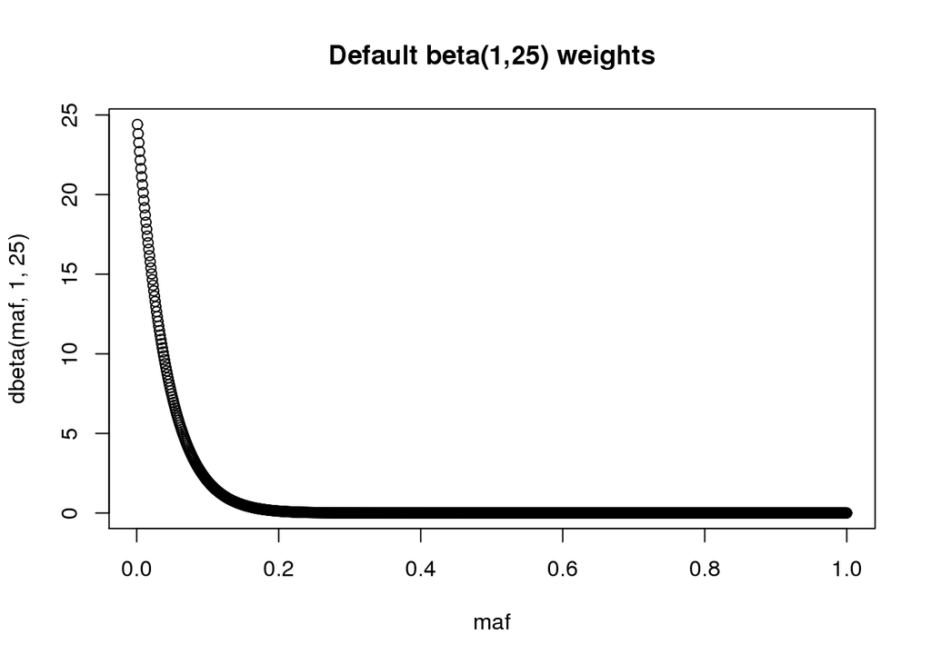

```r
# --- Default weight --- #
maf <- 1:1000/1000
plot(maf, dbeta(maf, 1, 25), main="Default beta(1,25) weights")
```

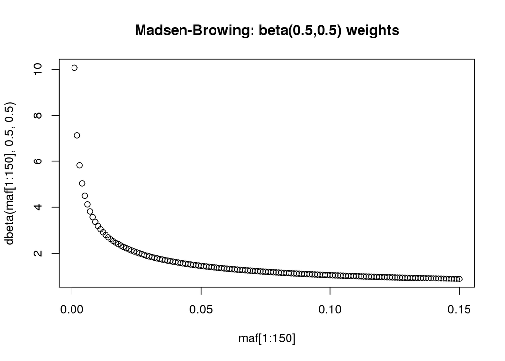

```r
plot(maf[1:150],
     dbeta(maf[1:150], 0.5, 0.5),
     main="Madsen-Browing: beta(0.5,0.5) weights")
```

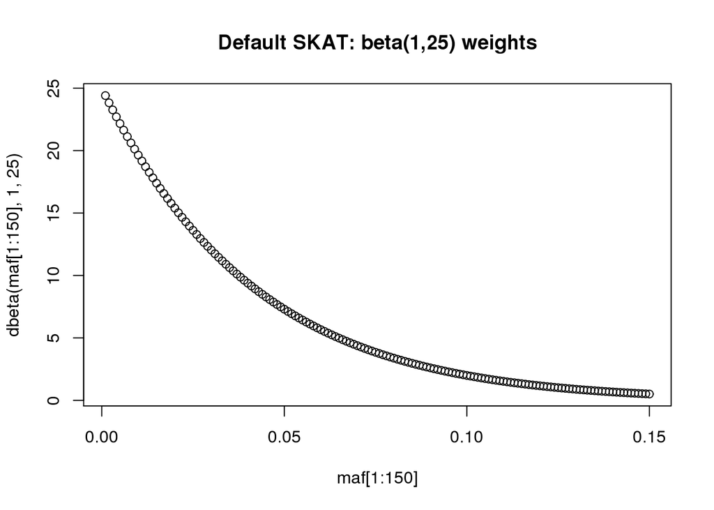

```r
plot(maf[1:150],
     dbeta(maf[1:150], 1, 25),
     main="Default SKAT: beta(1,25) weights")
```

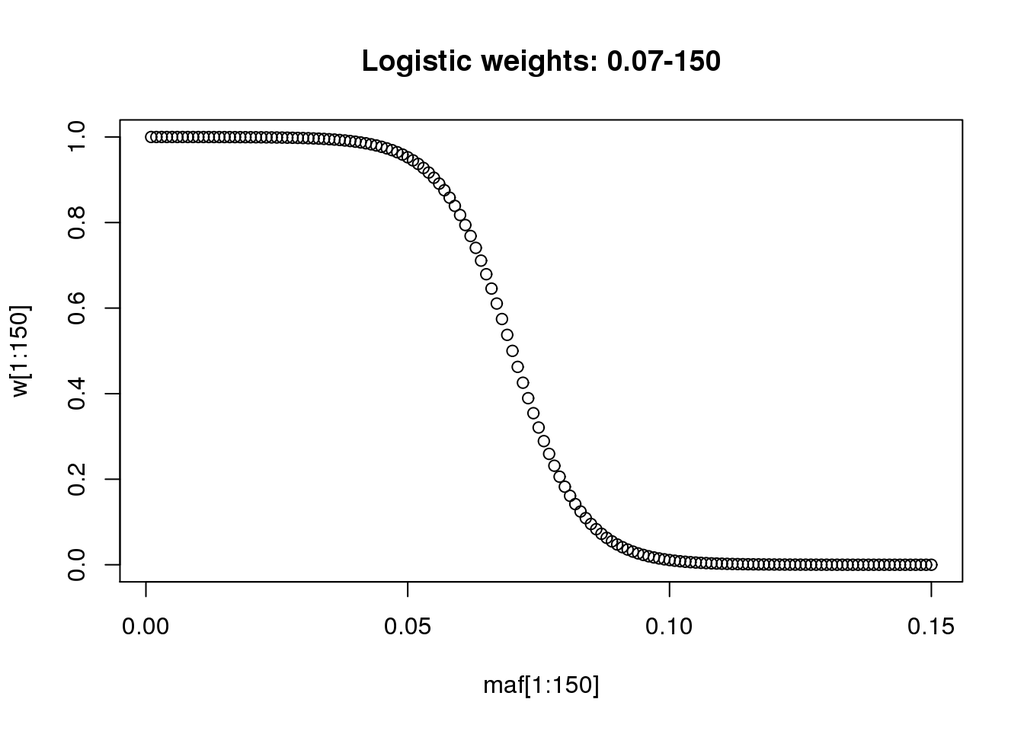

```r
w <- Get_Logistic_Weights_MAF(maf, 0.07, 150)
plot(maf[1:150],
     w[1:150],
     main="Logistic weights: 0.07-150")
```

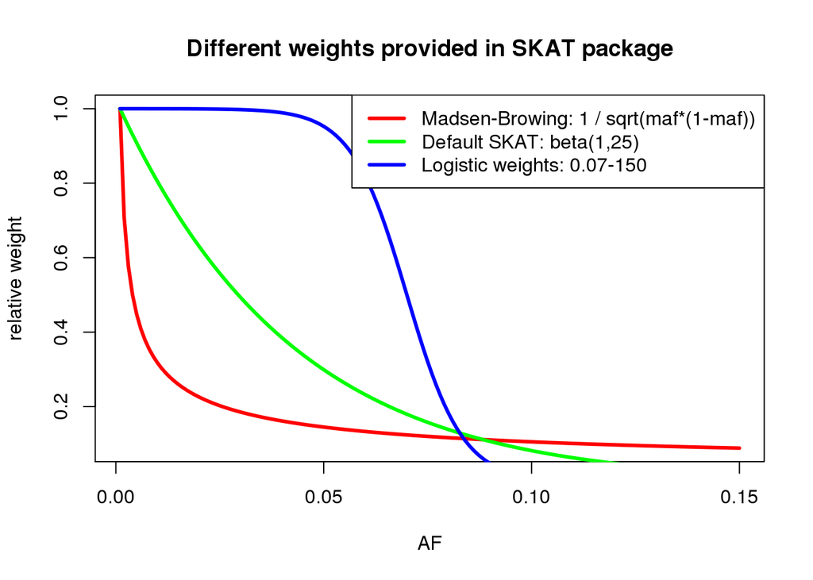

```r
# --- 3 weights selected for using in wecare --- #
plot(maf[1:150],
     dbeta(maf[1:150], 0.5, 0.5) / dbeta(maf[1], 0.5, 0.5),
     type="l", lwd=3, col="red",
     xlab="AF", ylab="relative weight",
     main="Different weights provided in SKAT package")
lines(maf[1:150], dbeta(maf[1:150], 1, 25) / dbeta(maf[1], 1, 25),
     type="l", lwd=3, col="green")
lines(maf[1:150], w[1:150],
      type="l", lwd=3, col="blue")

legend("topright",
       c("Madsen-Browing: 1 / sqrt(maf*(1-maf))",
         "Default SKAT: beta(1,25)",
         "Logistic weights: 0.07-150"),
       lty=c(1,1,1),
       lwd=c(3,3,3),
       col=c("red","green","blue"))
```

```r
# --- Weights at different alleles frequencies --- #

# Default SKAT weights: sharp drop in common variants
# Strong ~100x decrement in common 5-10-20% : 10-1-0.1
# Modest ~3x increment in rare 5-1-0.5% : 7-19-21
dbeta(0.2, 1, 25) # AF=20%
```

```
## [1] 0.1180592
```

```r
dbeta(0.125, 1, 25) # AF=12.5%
```

```
## [1] 1.014223
```

```r
dbeta(0.1, 1, 25) # AF=10%
```

```
## [1] 1.994161
```

```r
dbeta(0.05, 1, 25) # AF=5% - typical threshold between common and rare
```

```
## [1] 7.299726
```

```r
dbeta(0.01, 1, 25) # AF=1%
```

```
## [1] 19.64195
```

```r
dbeta(0.005, 1, 25) # AF=0.5% ~ minimal AF in wecare
```

```
## [1] 22.16634
```

```r
# Madsen-Browing weights: less decrement in common (5-20%)
# Modest ~3x decrement in common 5-10-20% : 1.4-1-0.7
# Modest ~3x increment in rare 5-1-0.5% : 1.5-3-4.5
dbeta(0.2, 0.5, 0.5) # AF=20%
```

```
## [1] 0.7957747
```

```r
dbeta(0.125, 0.5, 0.5) # AF=12.5%
```

```
## [1] 0.9624786
```

```r
dbeta(0.1, 0.5, 0.5) # AF=10%
```

```
## [1] 1.061033
```

```r
dbeta(0.05, 0.5, 0.5) # AF=5% - typical threshold between common and rare
```

```
## [1] 1.460506
```

```r
dbeta(0.01, 0.5, 0.5) # AF=1%
```

```
## [1] 3.199135
```

```r
dbeta(0.005, 0.5, 0.5) # AF=0.5% ~ minimal AF in wecare
```

```
## [1] 4.512878
```

# exploring_logistic_weights

Reasoning for 7%:150stipness logistic threshold:

1. Default used in SKAT documentation
2. Uses all rare (<5%) + allows common up to ~10%
3. with gradually reduced weights between 5 and 10%

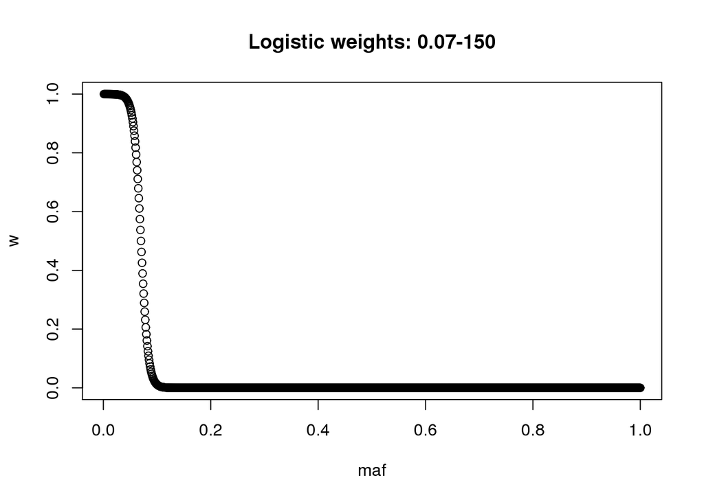

```r
w <- Get_Logistic_Weights_MAF(maf, 0.07, 150)
plot(maf, w, main="Logistic weights: 0.07-150")
```

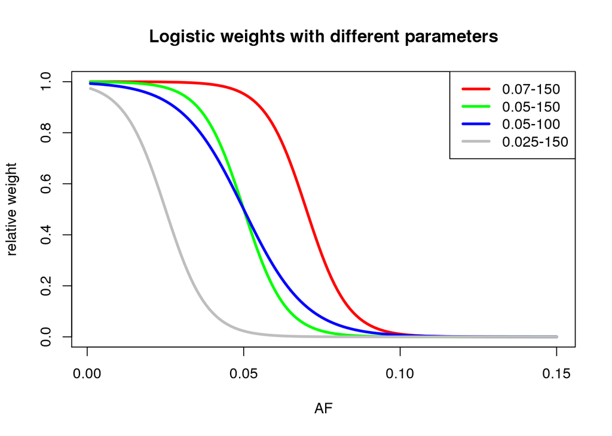

```r
plot(maf[1:150], w[1:150],
     type="l", lwd=3, col="red",
     xlab="AF", ylab="relative weight",
     main="Logistic weights with different parameters")

w <- Get_Logistic_Weights_MAF(maf, 0.05, 150)
lines(maf[1:150], w[1:150], type="l", lwd=3, col="green")

w <- Get_Logistic_Weights_MAF(maf, 0.05, 100)
lines(maf[1:150], w[1:150], type="l", lwd=3, col="blue")

w <- Get_Logistic_Weights_MAF(maf, 0.025, 150)
lines(maf[1:150],w[1:150], type="l", lwd=3, col="grey")

legend("topright",
       c("0.07-150",
         "0.05-150",
         "0.05-100",
         "0.025-150"),
       lty=c(1,1,1,1),
       lwd=c(3,3,3,3),
       col=c("red","green","blue", "grey"))
```

# exploring_Madsen_Browning_weight

Plots show weights for interval 0:1.

However, only the portion 0:0.5 is relevant for MAF (because AF > 0.5 is not minor any more).

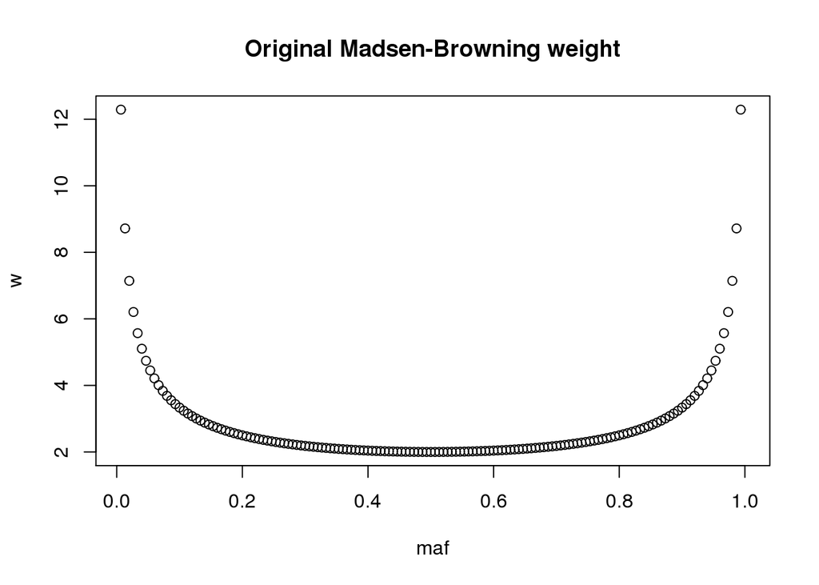

```r
maf <- c(1:150)/150
w <- 1 / sqrt(maf*(1-maf))
plot(maf,w,
     main="Original Madsen-Browning weight")
```

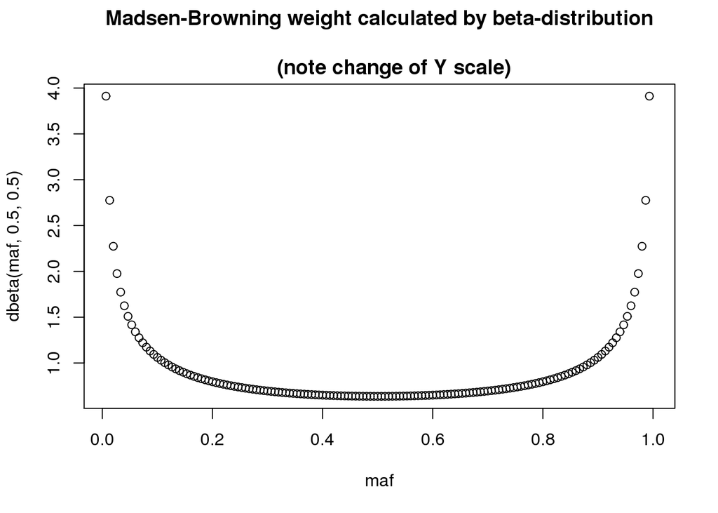

```r
plot(maf, dbeta(maf, 0.5, 0.5),
     main="Madsen-Browning weight calculated by beta-distribution\n
     (note change of Y scale)")
```

# SKATBinary

SKATBinary is the curently recommended function for using with binary phenotypes (Jul2016).

SKATBinary has convinience methods switches: “SKAT”, “Burden” and “SKATO” (method=“SKATO” assumes method=“optimal.adj” for SKAT).

SKATBinary preserves imputation and default weights as in original SKAT:  
default impute.method = “bestguess”, default weights are beta(1,25)

## SKATBinary has improved algorithms for p-value computation

It implements new faster algorithms for p-assessment with resampling, adjustment for small number of cases etc. Therefore it does not use/require the resampling calculation during the null model building (as would be used/required by the initial SKAT function).

### method.bin=“Hybrid”

This function implements six methods (method.bin) to compute p-values:  
1) Efficient resampling (ER);  
2) Quantile adjusted moment matching (QA);  
3) Moment matching adjustment (MA);  
4) No adjustment (UA);  
5) Adaptive ER (ER.A); and  
6) Hybrid.

“Hybrid” selects a method based on the total minor allele count (MAC), the number of individuals with minor alleles (m), and the degree of case-control imbalance.

When method.bin=“ER” or “ER.A”, SKATBinary compute mid-p-values and minimum achievable mid p-values.

### Two approaches to resampling

Resampling is used to estimate p from empirical data (a sort of clever permutation/bootstrapping that accounts for covariates) instead of estimating p from the analytical models.

For the “standard” SKAT function it requires resampling to be done at the stage of null model buildiing. Then it can be retrieved using “p.value.resampling”" etc.

However, SKATBinary implements it’s own resampling, which is not relevant to resampling during the null model building:

SKATBinary uses a recently developed efficient resampling (ER) approach to calculate p-values (manuscript currently under revision), which is a slightly different from traditional resampling methods. N.Resampling parameter in SKATBinary is for ER. If you want to use a traditional resampling approach, you need to use n.Resampling in SKAT_Null_Model.

https://groups.google.com/forum/#!topic/skat_slee/6Kl5mLRMRgY

```r
# Without adjustment in null model (as supposed)

system.time(
  skat.reg.null.no.aj <- SKAT_Null_Model(
    ph.s ~ c1.s + c2.s,
    Adjustment = FALSE,
    out_type="D")
)
```

```
##    user  system elapsed
##   0.007   0.000   0.007
```

```r
system.time(
  skat.reg.geno.no.aj.bin <- SKATBinary(
    gn.s,
    skat.reg.null.no.aj,
    kernel = "linear.weighted")
)
```

```
##    user  system elapsed
##   0.932   0.000   0.933
```

```r
skat.reg.geno.no.aj.bin$p.value
```

```
## [1] 0.1338838
```

```r
# With adjustment in null model (for comparison - just in case ...)

system.time(
  skat.reg.null.aj <- SKAT_Null_Model(
    ph.s ~ c1.s + c2.s,
    out_type="D")
)
```

```
## Sample size (non-missing y and X) = 200, which is < 2000. The small sample adjustment is applied!
```

```
##    user  system elapsed
##   1.383   0.000   1.383
```

```r
system.time(
  skat.reg.geno.aj.bin <- SKATBinary(
    gn.s,
    skat.reg.null.aj,
    kernel = "linear.weighted")
)
```

```
##    user  system elapsed
##   0.929   0.000   0.928
```

```r
skat.reg.geno.aj.bin$p.value
```

```
## [1] 0.1338838
```

# SKATBinary_Single

No need in combining anything, so no parameters to set rho and weights?

```r
system.time(
  skat.null.s <- SKAT_Null_Model(
    ph.s ~ c1.s + c2.s,
    Adjustment = FALSE,
    out_type="D")
)
```

```
##    user  system elapsed
##   0.008   0.000   0.007
```

```r
snp1.s <- as.vector(gn.s[,1])
snp5.s <- as.vector(gn.s[,5])

system.time(
  skat.reg.geno.single <- SKATBinary_Single(
    snp1.s,
    skat.null.s)
)
```

```
##    user  system elapsed
##   0.001   0.000   0.001
```

```r
skat.reg.geno.single$p.value
```

```
## [1] 1
```

```r
skat.reg.geno.single <- SKATBinary_Single(
  snp5.s,
  skat.null.s)

skat.reg.geno.single$p.value
```

```
## [1] 0.450276
```

# SKAT_CommonRare

This methods attempts to estimate combined effects of common and rare variants:

1. The threshold between common and rare variants is set to ~1-5% (default: 1/ √{2 SampleSize }). It is possible to set the common-rare threshold manually (CommonRare_Cutoff parameter).
2. Then different weights applied to common and rare (default SKAT to rare and MB to common). In both cases more frequent variants are underweighted.
3. Then statistics metric is calculated in a way that variances of rare and common contribute equally (method=“C”, default). This is done to remove potentially higher input of commons. It is also possible to make and “adaptive” algorithm for selecting relative inputs of common and rare (method=“A”). However, simulations showed that such adaptive algorithm somehow reduced power of the test (Ionita-Laza 2013).
4. Selection between burden and SKAT is set through “r.corr” parameters:  
   SKAT: r.corr.rare=0 & r.corr.common=0 (default)  
   burden: r.corr.rare=1 & r.corr.common=1
5. It seems that SKAT_CommonRare uses the original SKAT, not the SKATBinary, in the beck-end. Therefore it uses the old-style adjustment and resampling implementations, as described in the beginning of this tests’ summary. It seems that adjustment is the right way of calculations. Resampling looks not necessary, as it is very time-consuming, and it produces p-values quite symilar to the analytical estimates anyway.

```r
# With adjustment, w/o resampling

skat.null.s <- SKAT_Null_Model(
  ph.s ~ c1.s + c2.s,
  out_type="D")
```

```
## Sample size (non-missing y and X) = 200, which is < 2000. The small sample adjustment is applied!
```

```r
skatcr.test.s <- SKAT_CommonRare(
  gn.s,
  skat.null.s,
  method="C",
  r.corr.rare=0,
  r.corr.common=0)
# w/o adjustment, w/o resampling
skat.null.s.naj <- SKAT_Null_Model(
  ph.s ~ c1.s + c2.s,
  Adjustment=FALSE,
  out_type="D")

skatcr.test.s.naj <- SKAT_CommonRare(
  gn.s,
  skat.null.s.naj,
  r.corr.rare=0,
  r.corr.common=0)
# with adjustment, with resampling
system.time(
  skat.null.s.rs <- SKAT_Null_Model(
    ph.s ~ c1.s + c2.s,
    n.Resampling=100000,
    out_type="D")
)
```

```
## Sample size (non-missing y and X) = 200, which is < 2000. The small sample adjustment is applied!
```

```
##    user  system elapsed
##  15.171   0.078  15.249
```

```r
system.time(
  skatcr.test.s.rs <- SKAT_CommonRare(
    gn.s,
    skat.null.s.rs,
    r.corr.rare=0,
    r.corr.common=0)
)
```

```
##    user  system elapsed
##   1.019   0.037   1.056
```

```r
# Compare results

skatcr.test.s$p.value
```

```
## [1] 0.06966015
```

```r
skatcr.test.s.naj$p.value
```

```
## [1] 0.07682054
```

```r
skatcr.test.s.rs$p.value
```

```
## [1] 0.06861819
```

```r
#Get_Resampling_Pvalue(skatcr.test.s) # error: no resampling was done in null model
Get_Resampling_Pvalue(skatcr.test.s.rs)
```

```
## $p.value
## [1] 0.07244928
##
## $is_smaller
## [1] FALSE
```

# suggested_skat_calls

11 versions of SKAT test settings look equally valid, all of them will be run for comparison:

Burden, SKAT and SKATO with 3 different weights each: default, MB & logistic. SKATRC in burden and SKAT modes

Each will be applied to strict, medium and relaxed datasets.

If there is a single variant per gene, then SKATBinary_Single will be used.

The example below shows SKAT calculations, which can easily be changed to SKATO and Burden

```r
phenotype <- ph.s
covariates <- cbind(c1.s, c2.s)
genotypes <- gn.s

skat.null <- SKAT_Null_Model(
  phenotype ~ covariates,
  Adjustment=FALSE,
  out_type="D")

skat.test.df_wt <- SKATBinary(
  genotypes,
  skat.null,
  method="SKAT", # default, to be changed to "Burden" or "SKATO" when necessary
  weights.beta=c(1,25)) # default
skat.test.mb_wt <- SKATBinary(
  genotypes,
  skat.null,
  method="SKAT", # default, to be changed to "Burden" or "SKATO" when necessary
  weights.beta=c(0.5,0.5))
lw <- Get_Logistic_Weights(
  genotypes, 0.07, 150)

skat.test.lw_wt <- SKATBinary(
  genotypes,
  skat.null,
  method="SKAT", # default, to be changed to "Burden" or "SKATO" when necessary
  weights=lw)
# Compare outputs (see more outputs later)
skat.test.df_wt$p.value
```

```
## [1] 0.1338838
```

```r
skat.test.mb_wt$p.value
```

```
## [1] 0.06499103
```

```r
skat.test.lw_wt$p.value
```

```
## [1] 0.4255702
```

```r
# Some default settings implied in each call:
# kernel = "linear.weighted"
# N.Resampling=2 *10^6
# missing_cutoff=0.15
# impute.method = "bestguess"
# method.bin="Hybrid"
```

# suggested_SKAT_CommonRare_calls

- with adjustment
- w/o resampling
- using default weights for rare [ beta(1,25) ] and common [ beta(0.5, 0.5) ]
- doing two tests: for burden and skat methods

```r
phenotype <- ph.s
covariates <- cbind(c1.s, c2.s)
genotypes <- gn.s

skat.null <- SKAT_Null_Model(
  phenotype ~ covariates,
  out_type="D")
```

```
## Sample size (non-missing y and X) = 200, which is < 2000. The small sample adjustment is applied!
```

```r
cr.test.skat <- SKAT_CommonRare(
  genotypes,
  skat.null,
  r.corr.rare=0,
  r.corr.common=0)
cr.test.burden <- SKAT_CommonRare(
  genotypes,
  skat.null,
  r.corr.rare=1,
  r.corr.common=1)
# Compare outputs (see more outputs later)
cr.test.skat$p.value
```

```
## [1] 0.06974739
```

```r
cr.test.burden$p.value
```

```
## [1] 0.2471971
```

```r
#cr.test.skat
#cr.test.burden

# Some default settings implied in each call:
# method="C" - equla contribution of rare and common variances
# kernel = "linear.weighted"
# etc
```

# suggested_SKATBinary_Single_calls

No need in combining anything, so no parameters to set rho and weights?

```r
phenotype <- ph.s
covariates <- cbind(c1.s, c2.s)
genotypes <- gn.s

skat.null <- SKAT_Null_Model(
  phenotype ~ covariates,
  Adjustment = FALSE,
  out_type="D")

variant1 <- as.vector(genotypes[,1])
variant2 <- as.vector(genotypes[,5])

skat.test.single.var1 <- SKATBinary_Single(
  variant1, skat.null)
skat.test.single.var2 <- SKATBinary_Single(
  variant2, skat.null)

skat.test.single.var1$p.value
```

```
## [1] 1
```

```r
skat.test.single.var2$p.value
```

```
## [1] 0.450276
```

```r
#skat.test.single.var2
```

# Other notes

## FWER correction for p-value

There is an option of p-value correction, called Family-Wide:  
Resampling_FWER(skat.geno.s)  
It can not be used in wecare because it only implements in SKAT.SSD context.

## SKAT_ChrX

Allows special processing of X-chr variants depending on gender.  
Not needed for wecare because this dataset is of female gender only.

## Outputs

See “value” for skat test objects to pick what to report: done in a separate file

# final_section

```r
Sys.time()
```

```
## [1] "2016-07-18 15:06:08 BST"
```